# Exercise class prediction based on measurements from wearable devices

Phil Allen

28 February 2016

# Summary

I studied the data set described in Ugulino, W.; Cardador, D.; Vega, K.; Velloso, E.; Milidiu, R.; Fuks, H. [Wearable Computing: Accelerometers’ Data Classification of Body Postures and Movements](http://groupware.les.inf.puc-rio.br/public/papers/2012.Ugulino.WearableComputing.HAR.Classifier.RIBBON.pdf), Proc. 21st Brazilian Symposium on Artificial Intelligence, Advances in Artificial Intelligence - SBIA 2012.

Ugulino et al. attempt a form of Human Activity Recognition using measurements from wearable devices. Subjects performed exercises while wearing measurement devices. They were asked to perform in several *classes*, that is correctly, and with some common errors. The objective of the study was to predict the class of exercise using data collected from the measurement devices.

Using their [raw data](https://d396qusza40orc.cloudfront.net/predmachlearn/pml-training.csv), I attempted a similar prediction. Using the R [caret](http://topepo.github.io/caret/index.html) package, I tidied the data, separated a validation set, applied pre-processing to reduce dimensionality, and trained a Random Forest model.

The error rate on the validation set was 2.2%.

# Clean the data

```r
training <- read.csv("pml-training.csv", stringsAsFactors = FALSE, header = TRUE)
```

The data comprises the outcome classe, the subject name, timestamps, (capture) window data, and real-valued static and dynamic measures. Classify the data appropriately.

```r
training_classe <- as.factor(training$classe)
training$user_name <- as.factor(training$user_name)
training$new_window <- as.factor(training$new_window)
# turn literal datetimes into R timestamps
training$cvtd_timestamp <-
  as.numeric(strptime(training$cvtd_timestamp, format="%d/%m/%Y %H:%M"))
for (col in 8:ncol(training)) { training[,col] <- as.numeric(training[,col]) }
```

I suspect cvtd_timestamp is derived from raw_timestamp_part_1 , raw_timestamp_part_2.

```r
findLinearCombos(training[,c("raw_timestamp_part_1", "raw_timestamp_part_2", "cvtd_timestamp")])$remove
```

```
## [1] 3
```

This confirms that cvtd_timestamp is redundant, and can removed from the predictor set, along with the row number, the new window flag and the outcome.

```r
training_pp1 <- training[,-c(1,5,6,160)]
```

There is a great deal of missing data, mainly due to sparse measures rather than a scatter of rows.

```r
miss_rates <- apply(training_pp1, 2, function(x){mean(is.na(x))})
miss95 <- which(miss_rates > 0.95)
c(length(miss95), length(which(miss_rates > 0.01)))
```

```
## [1] 100 100
```

Note that the same number of measures are missing 95% of their values as are missing 1% of their values. So remove measures identified here from the set of predictors.

```r
training_pp1 <- training_pp1[,-miss95]
```

# Training and validation data sets

Now split out a validation set from training.

```r
set.seed(123)
in_train_idx <- createDataPartition(training_classe, p=0.7, list = FALSE)
valset_classe <- training_classe[-in_train_idx]
training_classe <- training_classe[in_train_idx]
valset_pp1 <- training_pp1[-in_train_idx,]
training_pp1 <- training_pp1[in_train_idx,]
```

# Pre-process to reduce dimensionality of predictors

Of the remaining measures, many are heavily skewed, e.g. magnet_dumbbell_x.

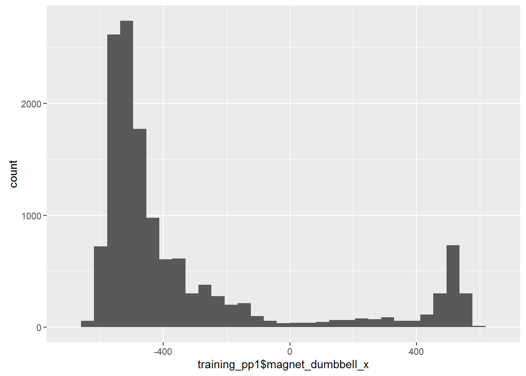

So apply [Yeo-Johnson](http://www.inside-r.org/packages/cran/VGAM/docs/yeo.johnson), which is similar to Box-Cox but tolerates negative values. Other measures have very small variance, so apply [nzv](http://www.inside-r.org/packages/cran/caret/docs/nearZeroVar). Finally, to cut down the number of predictors, apply [PCA](https://en.wikipedia.org/wiki/Principal_component_analysis) with a variance threshold of 90%.

```r
set.seed(456)
pp2 <- preProcess(training_pp1, method=c("YeoJohnson", "nzv", "pca"), thresh=0.9)
training_pp2 <- predict(pp2, newdata=training_pp1)
```

This leaves 24 predictors for use in model fitting.

# Training

Following the lectures, I decided to try Random Forests.

As [Breiman](http://www.stat.berkeley.edu/~breiman/RandomForests/cc_home.htm#ooberr) notes, there is no need to apply cross-validation to Random Forests. Also, Random Forests predictor in R provides an OOB error estimate. Therefore, I *could* use all of “training” for fitting, and use “testing” as the hold-out. However, for learning reasons, I will use distinct training and validation sets, as defined aove.

Train the model.

```r
mrfpp2 <- train(y=training_classe, x=training_pp2, method="rf")
```

# Validation: OOB error estimates

Apply the model to the validation set, making sure to pre-process.

```r
valset_pp2 <- predict(pp2, newdata=valset_pp1)
valset_pred <- predict(mrfpp2, newdata=valset_pp2)
confusionMatrix(valset_pred, valset_classe)
```

```
## Confusion Matrix and Statistics
##
##           Reference
## Prediction    A    B    C    D    E
##          A 1663   22    0    3    0
##          B    2 1097   24    6    7
##          C    1   16  996   24    2
##          D    4    2    5  931    5
##          E    4    2    1    0 1068
##
## Overall Statistics
##
##                Accuracy : 0.9779
##                  95% CI : (0.9738, 0.9815)
##     No Information Rate : 0.2845
##     P-Value [Acc > NIR] : < 2.2e-16
##
##                   Kappa : 0.972
##  Mcnemar's Test P-Value : 1.453e-06
##
## Statistics by Class:
##
##                      Class: A Class: B Class: C Class: D Class: E
## Sensitivity            0.9934   0.9631   0.9708   0.9658   0.9871
## Specificity            0.9941   0.9918   0.9912   0.9967   0.9985
## Pos Pred Value         0.9852   0.9657   0.9586   0.9831   0.9935
## Neg Pred Value         0.9974   0.9912   0.9938   0.9933   0.9971
## Prevalence             0.2845   0.1935   0.1743   0.1638   0.1839
## Detection Rate         0.2826   0.1864   0.1692   0.1582   0.1815
## Detection Prevalence   0.2868   0.1930   0.1766   0.1609   0.1827
## Balanced Accuracy      0.9937   0.9775   0.9810   0.9813   0.9928
```

```r
valset_acc <- mean(valset_pred != valset_classe)
```

The OOB error estimate given by the accuracy of the validation set is 2.21%.

# Quiz examples

Clean and pre-process the test data in the same way as the training data above.

```r
testing <- read.csv("pml-testing.csv", stringsAsFactors = FALSE, header = TRUE)
testing$user_name <- as.factor(testing$user_name)
for (col in 8:ncol(testing)) { testing[,col] <- as.numeric(testing[,col]) }
testing_pp1 <- testing[,-c(1,5,6,160)]
testing_pp1 <- testing_pp1[,-miss95]
testing_pp2 <- predict(pp2, newdata=testing_pp1)
```

The predictions for the quiz are:

```r
testing_preds <- predict(mrfpp2, newdata=testing_pp2)
as.character(testing_preds)
```

```
##  [1] "B" "A" "B" "A" "A" "E" "D" "B" "A" "A" "B" "C" "B" "A" "E" "E" "A"
## [18] "B" "B" "B"
```